# Practicals 07: Clustering and transcriptomics

BE_22 Bioinformatics SS 21

January Weiner

2022-06-09

### Installation

First, we need to install a few packages. We will also install DESeq2 (Bioconductor package), because we will need it during following practicals.

```r
install.packages("cluster")
BiocManager::install("DESeq2")
```

This will take a moment, during which we will talk about what the plan for the practicals is.

## Clustering

### K-means clustering

You will cluster the iris data set. First, because we know exactly how many clusters should there be, and second, because you have seen it before. How well can the different clustering algorithms figure out how the real groups look like?

Before we start clustering, we will take a look again at the data set using a PCA approach (see practicals 5).

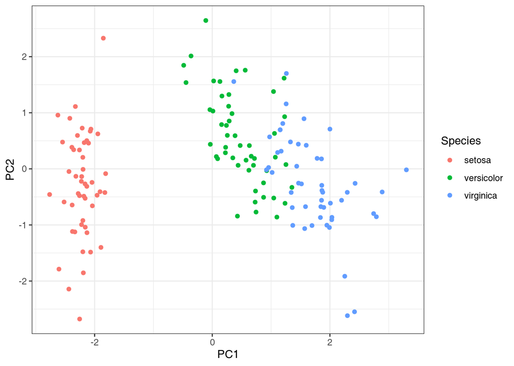

```r
## first, a quick look
View(iris)

library(ggplot2)
data(iris) ## not necessary in newer R versions
pca <- prcomp(iris[, 1:4], scale.=TRUE)
## what does the following line do?
df <- data.frame(iris, pca$x[,1:4])
ggplot(df, aes(x=PC1, y=PC2, color=Species)) + geom_point()
```

Now, let us cluster the data. We will start with the kmeans algorithm. The `kmeans` function is part of base R. Remember, in the iris data set the first four columns are numerical. We start with 3 clusters (as we expect to get 3 clusters!).

```r
iris_mtx <- iris[,1:4]
clusts_kmeans <- kmeans(iris_mtx, centers=3)
```

**Exercise (5’).** What is the type of the `clusts_kmeans` object? What components does it have? Take a look at the `clusts_kmeans$cluster`. What do you think that is?

Now, let us take a look how the cluster assignment compares to the actual clusters. First, let us visualize the clustering. We will use the previously calculated principal components, but color by cluster (and not Species):

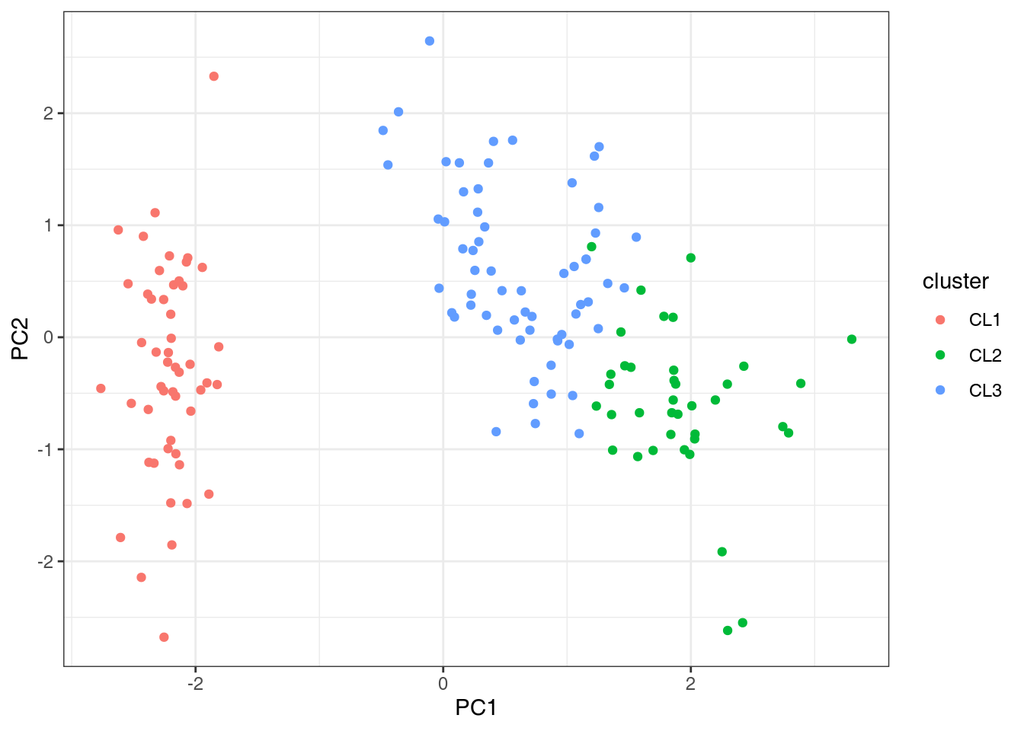

```r
df <- data.frame(iris, pca$x[,1:4], cluster=paste0("CL", clusts_kmeans$cluster))
ggplot(df, aes(x=PC1, y=PC2, color=cluster)) + geom_point()
```

This looks similar, but is it? The `table` function in R is very useful to create contingency tables which show us how many elements of each Species are assigned to which cluster:

```r
table(df$Species, df$cluster)
```

```
##
##              CL1 CL2 CL3
##   setosa      50   0   0
##   versicolor   0   2  48
##   virginica    0  36  14
```

**Exercise (15’).** Create clustering with 2, 4 and 5 clusters. Create plots as above and contingency tables.

The elements `withinss`, `betweenss` and `totss` give the within, between and total sums of squares. We can see that sum of the within and between sums of squares is equal to the total sum of squares:

```r
sum(clusts_kmeans$withinss) + clusts_kmeans$betweenss # 681.37
clusts_kmeans$totss # also 681.37
```

We can create a series of clusterings and plot the fraction of withinss along the number of clusters:

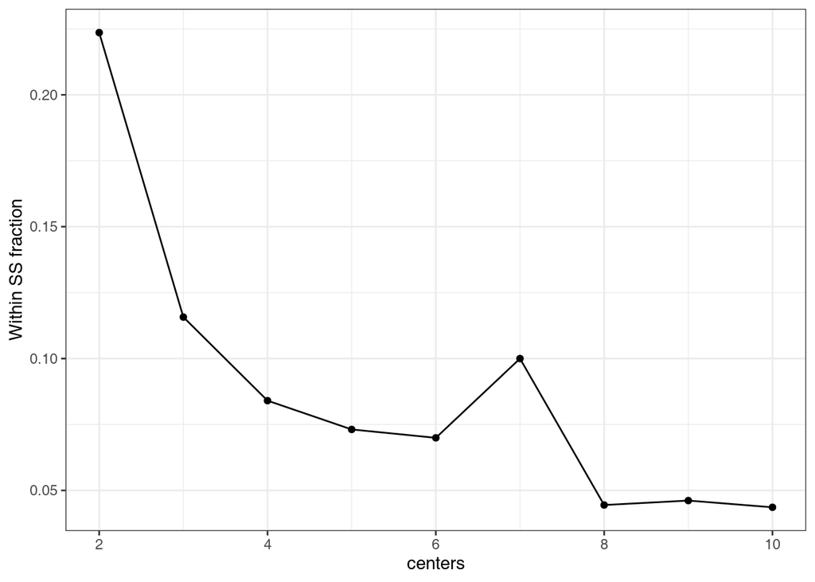

```r
n <- 2:10 # 2 to 10 cluster centres
cl <- lapply(n, function(i) kmeans(iris_mtx, centers=i))

## we use sapply to create a vector rather than a list
## you can also use map_dbl for that
calc_ss_fraction <- function(x) {
  withinss <- x$withinss
  totss    <- x$totss
  return(sum(withinss) / totss)
}
ss_frac <- sapply(cl, calc_ss_fraction)

df <- data.frame(centers=n, ss_frac=ss_frac)
ggplot(df, aes(x=centers, y=ss_frac, group=1)) + geom_point() +
  geom_line() + ylab("Within SS fraction")
```

**Exercise. (5’)** What number of clusters is optimal according to the elbow rule? Take a look at the code above. Do you understand how it works? If not, ask!

### Hierarchical clustering

The R function `hclust` is really useful here. However, to use it, we need to convert the iris data into a distance matrix (see practicals 6).

```r
iris_dist <- dist(iris_mtx)
tree_hclust <- hclust(iris_dist)
```

**Exercise. (5’)**. What happens if you simply run `plot(tree_hclust)`? Take a look at the help page for hclust (`?hclust`). How do you add labels to the plot? Add `iris$Species` as labels.

The `tree_hclust` object does not contain the clusters. To actually get the clusters, we need to cut the tree, specifying either a number of clusters that we want to have or a height at which we want to cut the tree.

```r
clusts_h <- cutree(tree_hclust, k=3)
```

The result is a numerical vector with the cluster assignments.

**Exercise (10’).** Using `table` for creating contingency tables, compare the results of the clustering with hclust with (i) real species and (ii) results of the k-means clustering.

### Silhouettes

To visualise and calculate silhouettes, we need to have a distance matrix even for k-means clustering.

To visualize the silhouette, we use the `silhouette` function from the `cluster` package. Again, we need the distances in order to calculate the silhouette.

```r
library(cluster)
silh <- silhouette(clusts_kmeans$cluster, iris_dist)
head(silh)
```

```
##      cluster neighbor sil_width
## [1,]       1        3 0.8529551
## [2,]       1        3 0.8154948
## [3,]       1        3 0.8293151
## [4,]       1        3 0.8050139
## [5,]       1        3 0.8493016
## [6,]       1        3 0.7482804
```

```r
print(mean(silh[,3]))
```

```
## [1] 0.552819
```

The `silh` object is basically a data frame with the individual silhouette widths in the third column. The average silhouette width over all elements is another way of measuring the clustering performance. We can calculate the average silhouette widths for clusters with differernt number of centers:

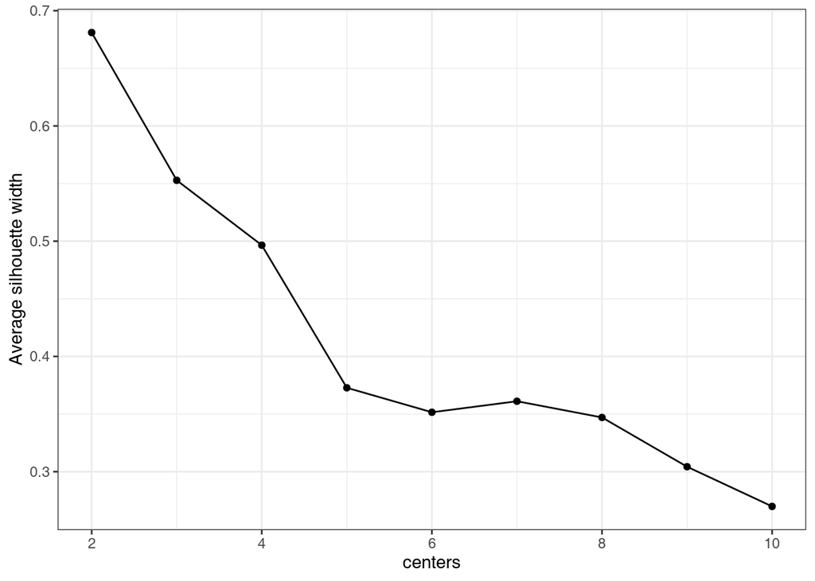

```r
avg_sil <- sapply(cl, function(x) {
                    x_sil <- silhouette(x$cluster, iris_dist)
                    return(mean(x_sil[,3]))
})
df <- data.frame(centers=n, silwidth=avg_sil)
ggplot(df, aes(x=centers, y=silwidth, group=1)) + geom_point() +
  geom_line() + ylab("Average silhouette width")
```

If we use the silhouette method for determining the optimal number of clusters, then the result would be “2”.

**Homework 5.** Install the package `cluster.datasets`. In it, you will find the data set “european.foods”:

```r
install.packages("cluster.datasets")
library(cluster.datasets)
data(european.foods)
?european.foods
```

This is data frame showing percentages of housholds in several countries which have the given food at the time when the questionnaire was filled out; eg. 88% of the households in West Germany had teabags, but only 61% households in Austria. Cluster the countries by the foods; how many clusters do you see? You are free to use whichever method is available. Submit the assignment as an Rmarkdown file. Alternatively, use your own data set – whatever you like (except for iris data set, obviously).